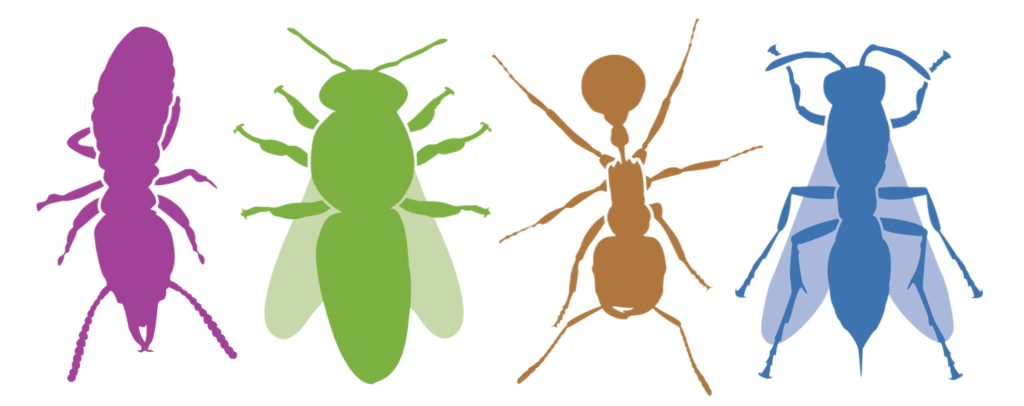

# IUSSI-NAS DEIJ Committee

[IUSSI-NAS website](https://iussi.cyberbee.net/) Email DEIJ committee

### *Diversity, Equity, Inclusion, and Justice* committee for the IUSSI North American section.

The IUSSI-NAS believes that everyone, regardless of identity (including race, gender, sexual orientation, socioeconomic class, ethnicity, religion, caste, age, nationality, and ability status), belongs in social insect science. Like the diversity found in a social insect society, having a diverse membership leads to better overall outcomes, and ultimately advances scientific knowledge. IUSSI-NAS is working to support diversity, accessibility, and inclusion efforts by creating opportunities for participation and advancement in social insect science as a whole and actively opposing racism and all other forms of discrimination and harassment. We will listen, learn from, and work with our members from all career stages and backgrounds to build a more diverse, equitable, inclusive, and just community of social insect researchers. You can reach out to the Diversity, Equity, Inclusion, and Justice (DEIJ) Committee anytime with thoughts and concerns.

Email: iussi.nas.deij@gmail.com.

# Upcoming / recent events

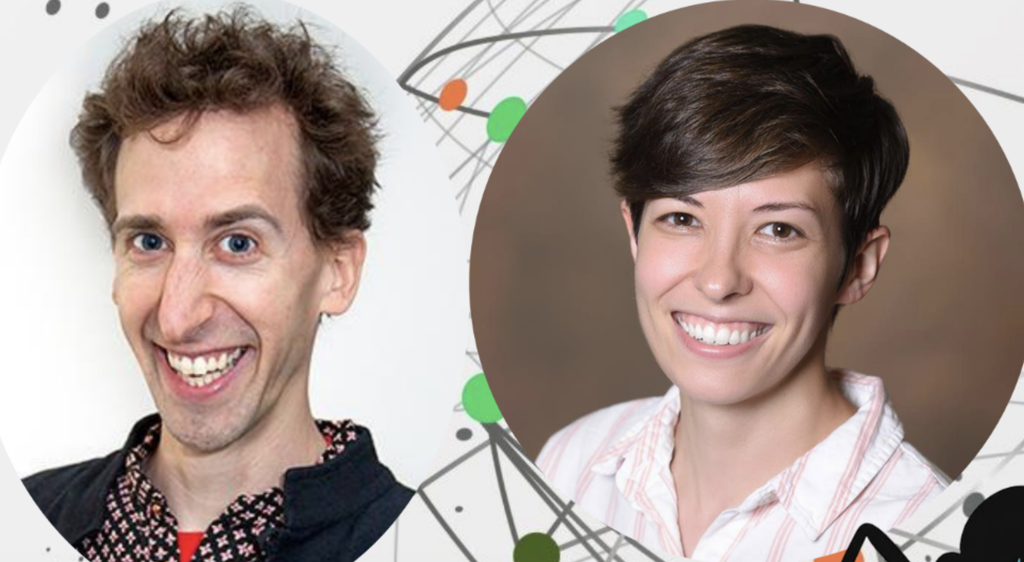

### Communicating Social Insect Science

Tips and tools for sharing our love of social insects with the world.

Dec 11, 2025

Barrett Klein, Kaitlin Baudier